# Module_01_Lesson_02 Solution

Romil Shah

05-15-2016

```r
require(ggplot2)
require(gridExtra)
require(moments)
require(reshape2)
```

## Solution to Question 1:

#### Cauchy Probability Density Function

```r
trials<-1000
cauchy_dist <-data.frame(cauchy1=rcauchy(n=trials,location=0, scale=0.5), cauchy2=rcauchy(n=trials, location=0, scale=1), cauchy3=rcauchy(n=trials, location=0,scale=2), cauchy4=rcauchy(n=trials, location=-2, scale=1))

cauchy<- melt(data=cauchy_dist, variable.name ="locationshape", value.name="x")
```

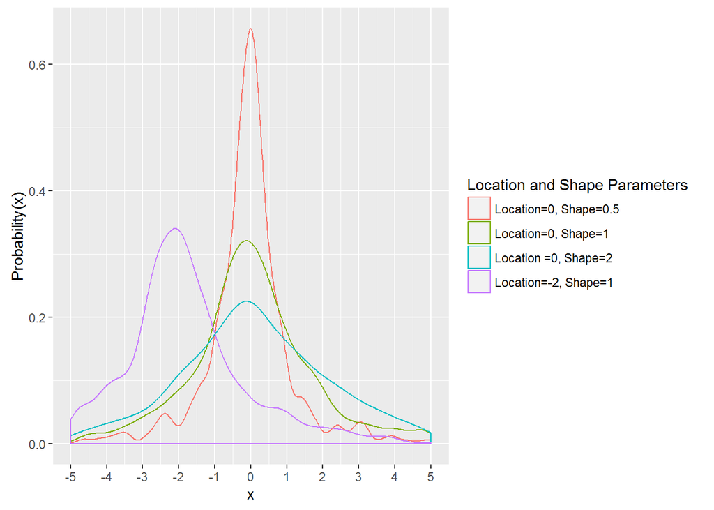

```r
qplot(data=cauchy, x=x, color=locationshape, geom='density')+scale_x_continuous(limits=c(-5,5),breaks=seq(-5,5,1))+ylab('Probability(x)')+ scale_color_discrete(name="Location and Shape Parameters", labels=c("Location=0, Shape=0.5","Location=0, Shape=1", "Location =0, Shape=2", "Location=-2, Shape=1"))
```

#### Cauchy Cumulative Density Function

```r
trials<-1000
cauchy_dist <-data.frame(cauchy1=rcauchy(n=trials,location=0, scale=0.5), cauchy2=rcauchy(n=trials, location=0, scale=1), cauchy3=rcauchy(n=trials, location=0,scale=2), cauchy4=rcauchy(n=trials, location=-2, scale=1))

cauchy<- melt(data=cauchy_dist, variable.name ="locationshape", value.name="x")
```

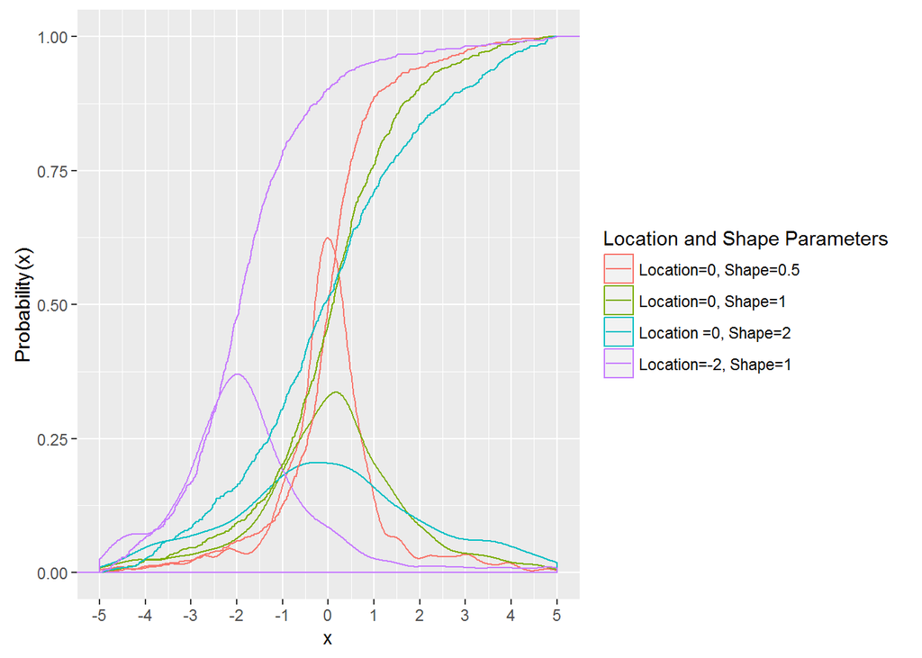

```r
qplot(data=cauchy, x=x, color=locationshape,geom='density')+stat_ecdf() +scale_x_continuous(limits=c(-5,5),breaks=seq(-5,5,1))+ylab('Probability(x)')+ scale_color_discrete(name="Location and Shape Parameters", labels=c("Location=0, Shape=0.5","Location=0, Shape=1", "Location =0, Shape=2", "Location=-2, Shape=1"))
```

## Solution to Question 2

Load the file M01_Lesson_02_Q1.csv

```r
q2_data<-read.csv(file="C:/Users/rams1/Desktop/DSCS6030/Module_01/M01_Lesson_02_Q1.csv")
str(q2_data)
```

```
## 'data.frame':    333 obs. of  6 variables:
##  $ X: int  1 2 3 4 5 6 7 8 9 10 ...
##  $ A: num  8.26 10.56 8.74 6.56 9.36 ...
##  $ B: num  -0.656 -0.716 0.8 1.583 1.027 ...
##  $ C: int  6 7 7 6 7 7 2 7 8 4 ...
##  $ D: int  8 8 5 10 8 12 10 10 9 5 ...
##  $ E: num  310 302 159 293 261 ...
```

```r
set.seed(333)
trials<-dim(q2_data)[1]
```

### Summary Stats

**Column: A**

```r
summary(q2_data$A)
```

```
##    Min. 1st Qu.  Median    Mean 3rd Qu.    Max.
##   3.902   7.793   9.072   9.079  10.390  14.790
```

```r
head(q2_data$A)
```

```
## [1]  8.257164 10.557378  8.744211  6.555028  9.362121  9.020671
```

```r
library(moments)
skewness(q2_data$A)
```

```
## [1] 0.1276357
```

```r
kurtosis(q2_data$A)
```

```
## [1] 2.804903
```

Data is continuous with positive skew thus data is shifted towards the right. Also the skew is less and the mean~median. Kurtosis < Gaussian thus sharper peak.

**Column: B**

```r
summary(q2_data$B)
```

```
##     Min.  1st Qu.   Median     Mean  3rd Qu.     Max.
## -3.17600 -0.63200  0.03412  0.03063  0.67030  2.96900
```

```r
head(q2_data$B)
```

```
## [1] -0.6560755 -0.7158294  0.7996107  1.5832173  1.0272024  0.7197130
```

```r
skewness(q2_data$B)
```

```
## [1] 0.06372024
```

```r
kurtosis(q2_data$B)
```

```
## [1] 3.096818
```

Data is continuous with positive skew thus data is shifted towards the right. Also the skew is less and the mean~median. Kurtosis ~ Gaussian thus nearly similar peak.

**Column: C**

```r
summary(q2_data$C)
```

```
##    Min. 1st Qu.  Median    Mean 3rd Qu.    Max.
##     2.0     5.0     6.0     6.3     7.0     9.0
```

```r
skewness(q2_data$C)
```

```
## [1] -0.3306065
```

```r
kurtosis(q2_data$C)
```

```
## [1] 2.784658
```

Data is discrete with negative skew thus data is shifted towards the left. Also the skew is less and the mean~median. Kurtosis < Gaussian thus sharper peak.

**Column: D**

```r
summary(q2_data$D)
```

```
##    Min. 1st Qu.  Median    Mean 3rd Qu.    Max.
##   2.000   7.000   9.000   8.919  11.000  18.000
```

```r
head(q2_data$D)
```

```
## [1]  8  8  5 10  8 12
```

```r
skewness(q2_data$D)
```

```
## [1] 0.4592872
```

```r
kurtosis(q2_data$D)
```

```
## [1] 3.131259
```

Data is discrete with positive skew thus data is shifted towards the right. Also the skew is less and the mean~median. Kurtosis > Gaussian thus rounded peak.

**Column: E**

```r
summary(q2_data$E)
```

```
##    Min. 1st Qu.  Median    Mean 3rd Qu.    Max.
##   33.52  112.30  194.10  185.90  258.40  331.80
```

```r
head(q2_data$E)
```

```
## [1] 309.67242 301.74808 158.75132 293.42639 261.03700  80.01178
```

```r
skewness(q2_data$E)
```

```
## [1] -0.08634286
```

```r
kurtosis(q2_data$E)
```

```
## [1] 1.85588
```

### Anomolies or Outliers

**Column: A**

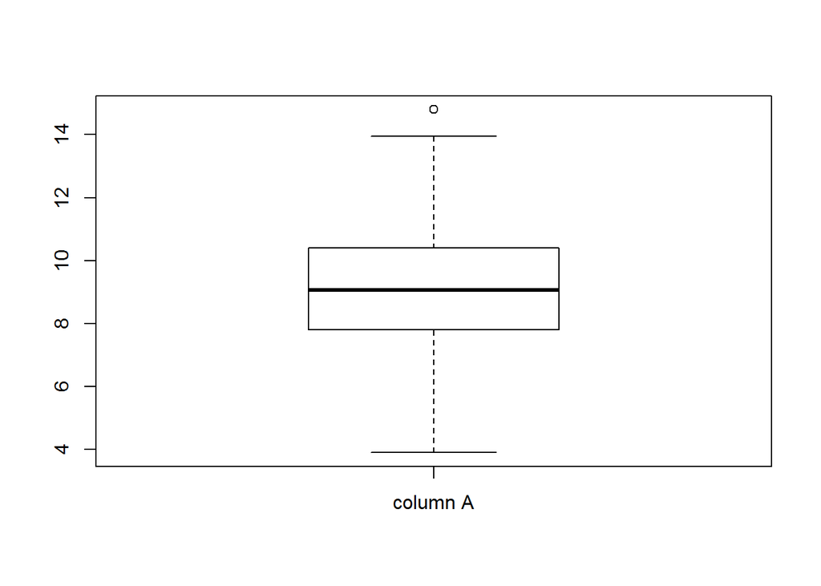

```r
# boxplot
boxplot(q2_data$A,names=c("column A"),show.names=T)
```

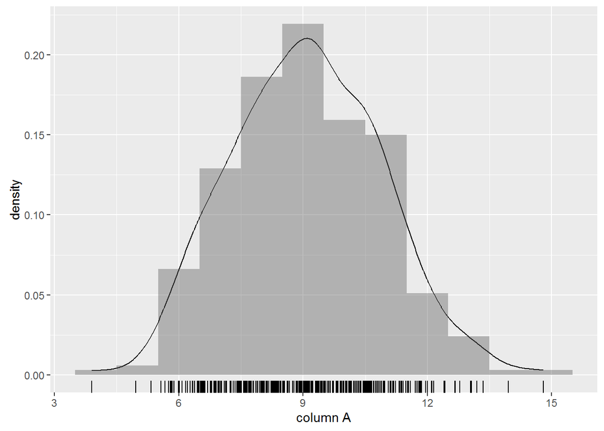

```r
# histogram
qplot(x=q2_data$A,data=q2_data,geom='blank') + geom_line(aes(y=..density..),stat='density') +
  geom_histogram(aes(y=..density..),alpha =0.4,binwidth=1) + labs(x = "column A") + geom_rug()
```

There is a possibility of an outlier based upon an unfilled circle seen on the top pf box plot.

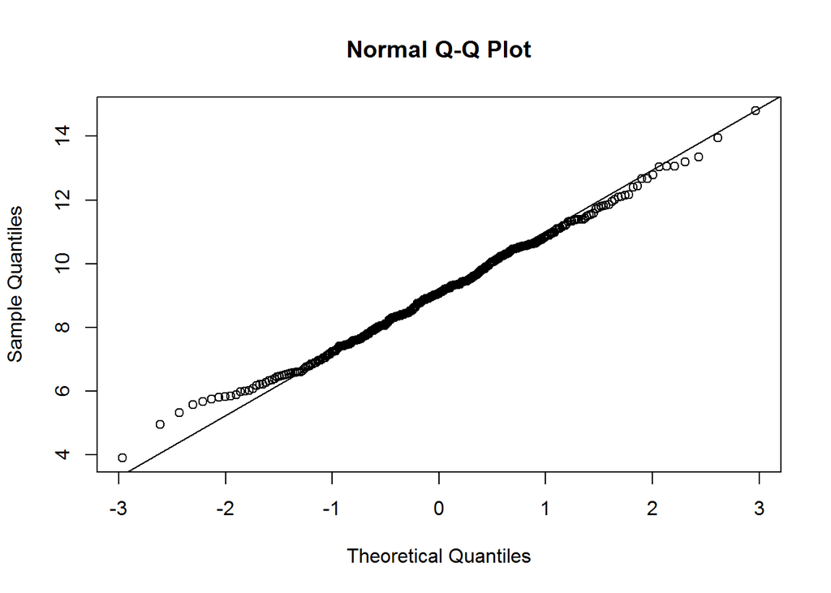

```r
qqnorm(q2_data$A)
qqline(q2_data$A)
```

The data looks more normally distributed.

**Column: B**

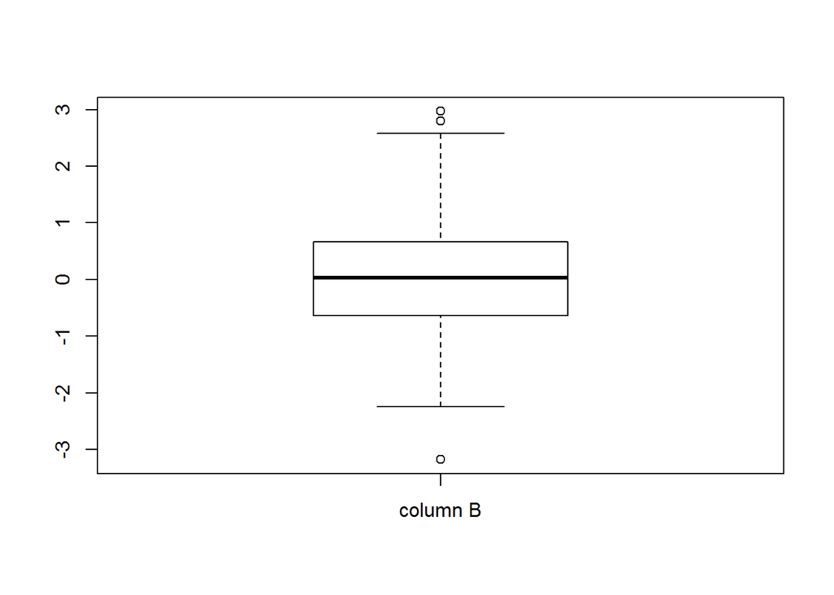

```r
# boxplot
boxplot(q2_data$B,names=c("column B"),show.names=T)
```

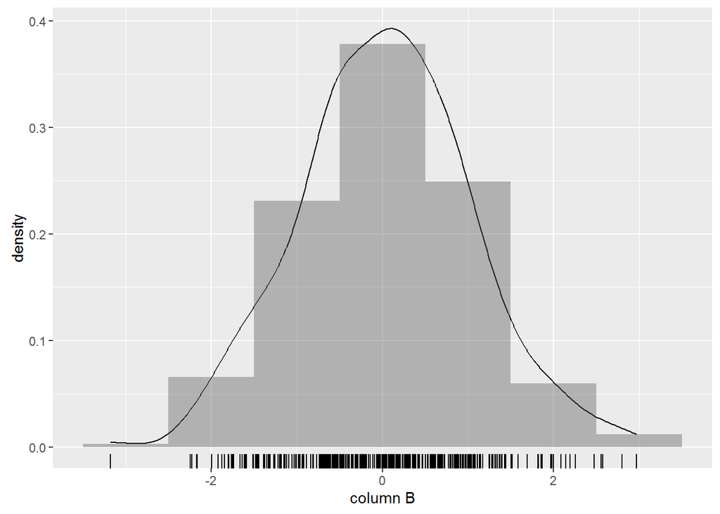

```r
# histogram
qplot(x=q2_data$B,data=q2_data,geom='blank') + geom_line(aes(y=..density..),stat='density') +
  geom_histogram(aes(y=..density..),alpha =0.4,binwidth=1) + labs(x = "column B") + geom_rug()
```

There are outliers based on the box plot.

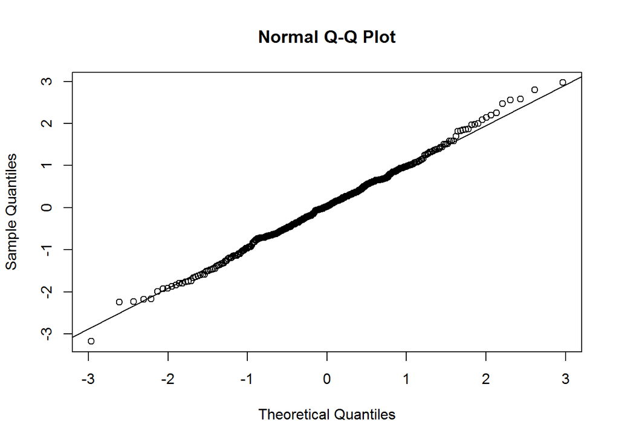

```r
qqnorm(q2_data$B)
qqline(q2_data$B)
```

The data seems to be normally distributed.

**Column: C**

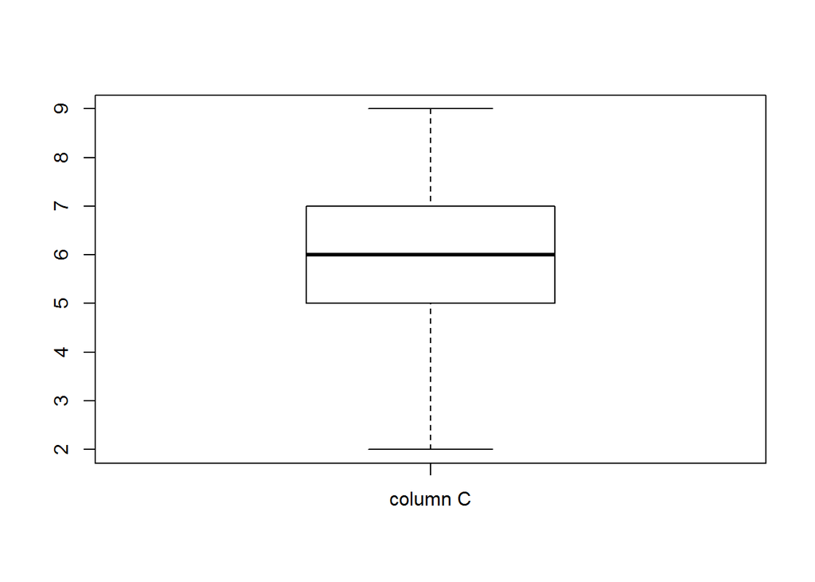

```r
# boxplot
boxplot(q2_data$C,names=c("column C"),show.names=T)
```

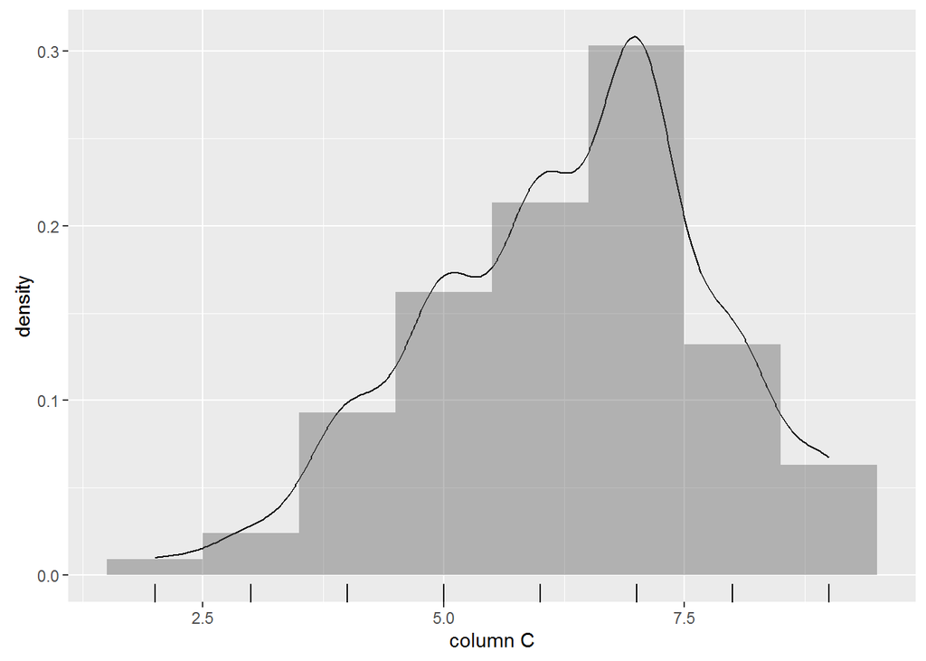

```r
# histogram
qplot(x=q2_data$C,data=q2_data,geom='blank') + geom_line(aes(y=..density..),stat='density') +
  geom_histogram(aes(y=..density..),alpha =0.4,binwidth=1) + labs(x = "column C") + geom_rug()
```

There seems to be no oulier from the box plot. The histogram shows that the data is not concentrated and as it is discrete it can be uniform discrete or binomial data.

**Column: D**

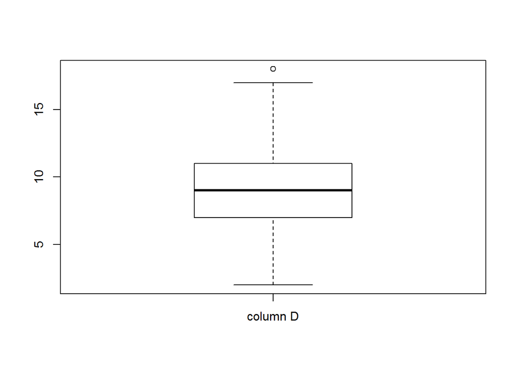

```r
# boxplot
boxplot(q2_data$D,names=c("column D"),show.names=T)
```

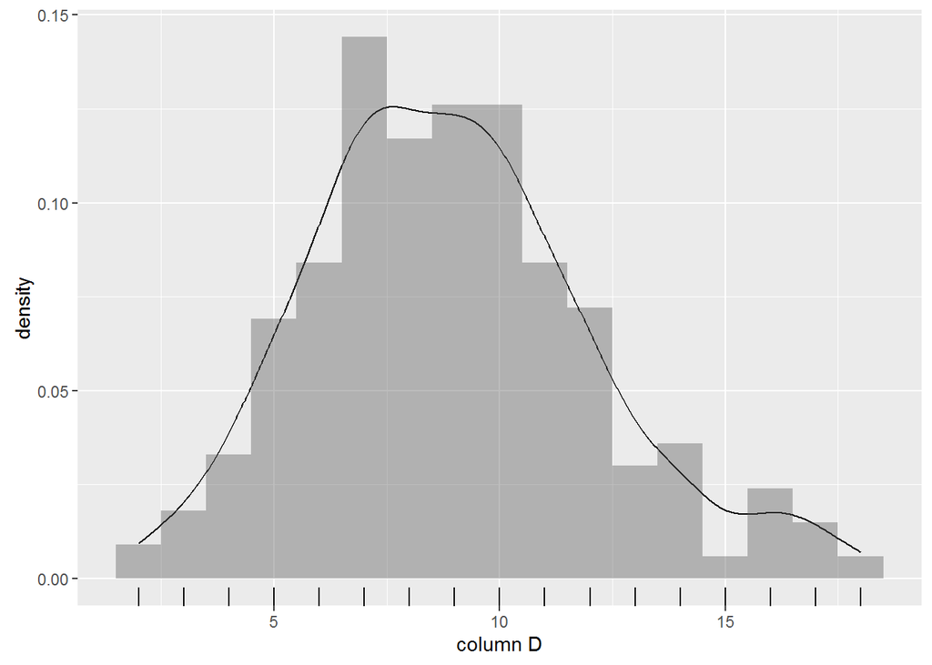

```r
# histogram
qplot(x=q2_data$D,data=q2_data,geom='blank') + geom_line(aes(y=..density..),stat='density') +
  geom_histogram(aes(y=..density..),alpha =0.4,binwidth=1) + labs(x = "column D") + geom_rug()
```

There seems to be an outlier based upon the box plot. The histogram shows that the data can be binomial as it is discrete.

**Column: E**

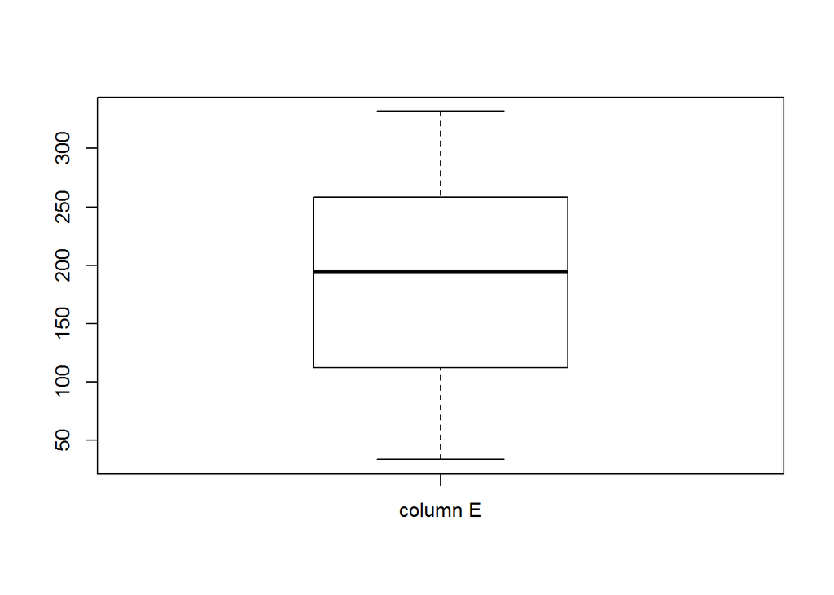

```r
# boxplot
boxplot(q2_data$E,names=c("column E"),show.names=T)
```

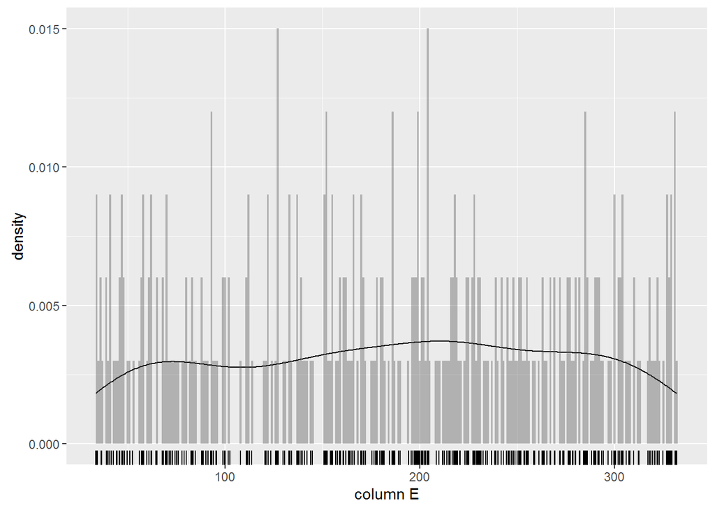

```r
# histogram
qplot(x=q2_data$E,data=q2_data,geom='blank') + geom_line(aes(y=..density..),stat='density') +
  geom_histogram(aes(y=..density..),alpha =0.4,binwidth=1) + labs(x = "column E") + geom_rug()
```

Based upon the box plot there seems to be no outliers. Also the histogram shows that the data can be uniformally distributed but continuous.

### Regeneration of Data

**Column: A**

```r
mean_A<-mean(q2_data$A)
sd_A<-sd(q2_data$A)
Recons_A<-rnorm(trials,mean=mean_A,sd=sd_A)
```

```r
summary(Recons_A)
```

```
##    Min. 1st Qu.  Median    Mean 3rd Qu.    Max.
##   4.699   8.042   9.277   9.217  10.290  15.140
```

```r
summary(q2_data$A)
```

```
##    Min. 1st Qu.  Median    Mean 3rd Qu.    Max.
##   3.902   7.793   9.072   9.079  10.390  14.790
```

Assuming to be normal distribution, the summary seems to be similar.

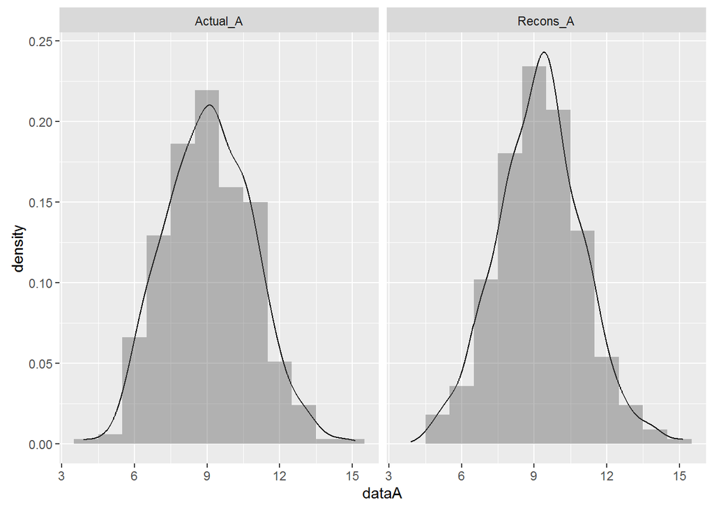

```r
dataA <- c(q2_data$A,Recons_A)
df_A <- data.frame(dataA,c(rep("Actual_A",333),rep("Recons_A",333)))
colnames(df_A) <- c("data","dist")
qplot(dataA,data=df_A,geom='blank') + facet_wrap(~dist) + geom_line(aes(y=..density..),stat='density') +
  geom_histogram(aes(y=..density..),alpha =0.4,binwidth=1)
```

The histogram comparison shows that they are quite similar.

**Column: B**

```r
mean_B<-mean(q2_data$B)
sd_B<-sd(q2_data$B)
Recons_B<-rnorm(trials,mean=mean_B,sd=sd_B)
```

```r
summary(Recons_B)
```

```
##     Min.  1st Qu.   Median     Mean  3rd Qu.     Max.
## -3.07900 -0.51470  0.02898  0.08274  0.76900  2.86700
```

```r
summary(q2_data$B)
```

```
##     Min.  1st Qu.   Median     Mean  3rd Qu.     Max.
## -3.17600 -0.63200  0.03412  0.03063  0.67030  2.96900
```

Assuming to be normal distribution, the summary seems to be similar.

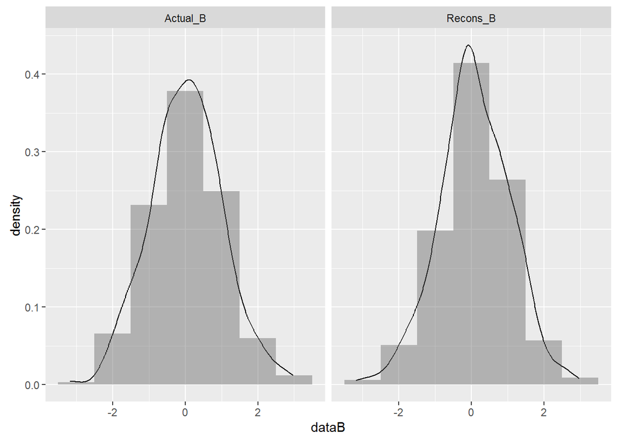

```r
dataB<-c(q2_data$B,Recons_B)
df_B<-data.frame(dataB,c(rep("Actual_B",333),rep("Recons_B",333)))
colnames(df_B)<-c("data","dist")
qplot(dataB,data=df_B,geom='blank') + facet_wrap(~dist) + geom_line(aes(y=..density..),stat='density') +
  geom_histogram(aes(y=..density..),alpha =0.4,binwidth=1)
```

The histogram comparison shows that they are quite similar.

**Column: C**

```r
Recons_C<-rbinom(n=trials,size=12,prob=0.5)
```

```r
summary(Recons_C)
```

```
##    Min. 1st Qu.  Median    Mean 3rd Qu.    Max.
##   2.000   5.000   6.000   5.964   7.000  11.000
```

```r
summary(q2_data$C)
```

```
##    Min. 1st Qu.  Median    Mean 3rd Qu.    Max.
##     2.0     5.0     6.0     6.3     7.0     9.0
```

Assuming to be binomial distribution, the summary seems to be similar. size and prob is obtained by repeated checks.

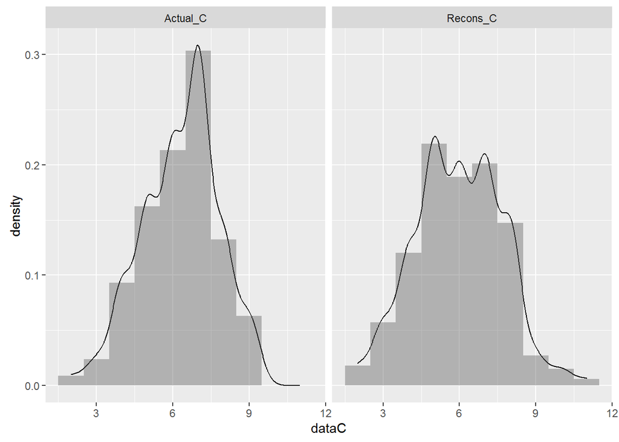

```r
dataC<-c(q2_data$C,Recons_C)
df_C<-data.frame(dataC,c(rep("Actual_C",333),rep("Recons_C",333)))
colnames(df_C)<-c("data","dist")
qplot(dataC,data=df_C,geom='blank') + facet_wrap(~dist) + geom_line(aes(y=..density..),stat='density') +
  geom_histogram(aes(y=..density..),alpha =0.4,binwidth=1)
```

The comparison shows quite similar structures.

**Column: D**

```r
Recons_D<-rbinom(n=trials,size=12,prob=0.4)
```

```r
summary(Recons_D)
```

```
##    Min. 1st Qu.  Median    Mean 3rd Qu.    Max.
##   0.000   4.000   5.000   4.841   6.000  10.000
```

```r
summary(q2_data$D)
```

```
##    Min. 1st Qu.  Median    Mean 3rd Qu.    Max.
##   2.000   7.000   9.000   8.919  11.000  18.000
```

Assuming binomial distribution the summary seems quite different.

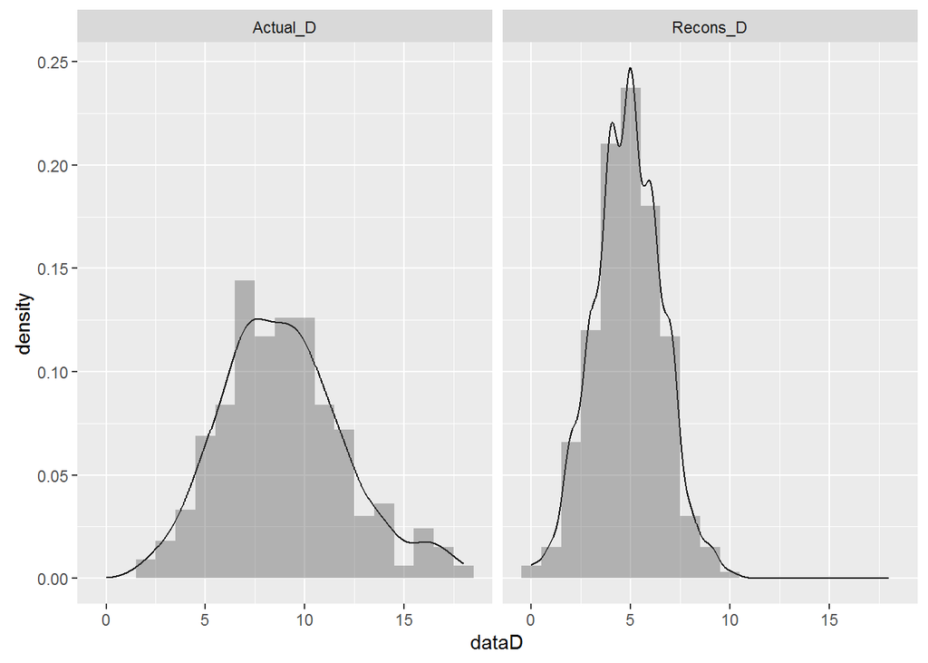

```r
dataD<-c(q2_data$D,Recons_D)
df_D<-data.frame(dataD,c(rep("Actual_D",333),rep("Recons_D",333)))
colnames(df_D)<-c("data","dist")
qplot(dataD,data=df_D,geom='blank') + facet_wrap(~dist) + geom_line(aes(y=..density..),stat='density') +
  geom_histogram(aes(y=..density..),alpha =0.4,binwidth=1)
```

**Column: E**

```r
Recons_E<-runif(n=trials,min=min(q2_data$E),max=max(q2_data$E))
```

```r
summary(Recons_E)
```

```
##    Min. 1st Qu.  Median    Mean 3rd Qu.    Max.
##   35.41  105.70  178.80  180.50  256.30  331.50
```

```r
summary(q2_data$E)
```

```
##    Min. 1st Qu.  Median    Mean 3rd Qu.    Max.
##   33.52  112.30  194.10  185.90  258.40  331.80
```

Assuming uniform distribution we can see there is similarity in the data.

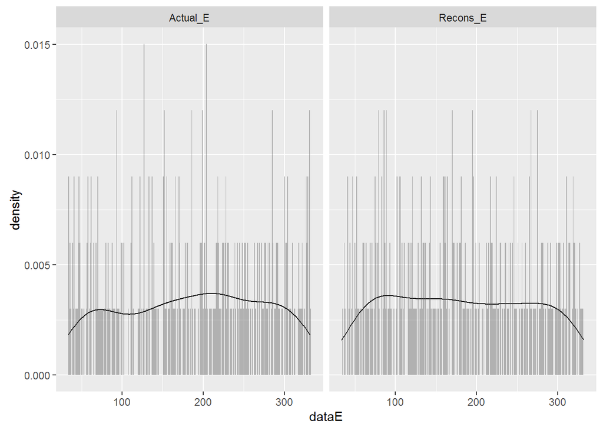

```r
dataE<-c(q2_data$E,Recons_E)
df_E<-data.frame(dataE,c(rep("Actual_E",333),rep("Recons_E",333)))
colnames(df_E)<-c("data","dist")
qplot(dataE,data=df_E,geom='blank') + facet_wrap(~dist) + geom_line(aes(y=..density..),stat='density') +
  geom_histogram(aes(y=..density..),alpha =0.4,binwidth=1)
```

The plots show good similar structure. Thus has to be uniform.